# Building graph Models

Nikitha Agarampalli(17232225)

March 16, 2018

## Overview

Twitter is an online news, microblogging and social networking service where millions of users post and interact with messages called tweets. A user can follow any number of users to receive their tweets and can retweet the same to spread the information of their choice beyond the reach of the original tweet’s followers.

The goal of this project is to collect the twitter data and study the topological characteristics of various tweets from the users through various benchmark graph models. The base network graph is plotted and its properties are compared with the plots and properties of the benchmark graph models.

We have used three equivalent benchmark graph models as follows:

1. Random (G(N,p)) Model
2. Small World Model(Lattice and Rewired Model)
3. Preferential Attachment Model

The three major characteristics of the network graph is obtained for all the models and compared to understand the differences and similarities. The following properties are calculated:

1. Degree Distribution
2. Average Path Length
3. Cluster Coefficient

We have crawled through the entire twitter site and obtained top ‘n’ number of tweets based on a search term. The data such as the tweets, retweets and their sources are extracted and stored in a dataframe. Based on the dataframe, network graphs are plotted to understand the links between the tweets and determine various measurements.

## Crawling the Twitter Dataset

```r
# Loading the necessary packages to connect to Twitter and retrieve the data

library(devtools)
library(twitteR)
library("igraph")
library("stringr")
library(ggplot2)
```

```r
# Providing the credentials to connect to my Twitter account

api_key="bz0yLx1IVhb7ZttweqnnxNI0d"
api_secret="puIMZVGnV7ENCqW0Wzf45tZntTcwDloZmSxCJ4Hr6nrZsajiWt"
access_token="2194357634-lylG93bIoSrfBpT5WPW9FCxHB1PcC8t4k1NQBZy"
access_token_secret="AMVS5RZr8HboylxRwrHcBEmCRTKEewWipZBqeKPojolBF"

# Authenticating and accessing the twitter account of the user details provided above

setup_twitter_oauth(api_key,api_secret,access_token,access_token_secret)
```

```
## [1] "Using direct authentication"
```

```r
# Retrieving top 100 tweets based on the below search term

tweets <- searchTwitter("Behindwoods", n=220, lang="en")

# Getting the text and identifying the retweeted data

get_text <-  sapply(tweets, function(x) x$getText())

grep("(RT|via)((?:\\b\\W*@\\w+)+)", tweets,
     ignore.case=TRUE, value=TRUE)
```

```
## character(0)
```

```r
tweets_pattern <- grep("(RT|via)((?:\\b\\W*@\\w+)+)",
                   get_text, ignore.case=TRUE)

head(get_text[tweets_pattern],10)
```

```
##  [1] "RT @behindwoods: \"#Vijay Can Remake #BharatAneNenu\" - Art Director #SureshSelvarajan Reveals | #RetweetWithRukshanth | @cinemavaarisu https"
##  [2] "RT @jcbibin1: #Thalapathy #Vijay Wins #PeoplesBiggestIconofTamilCinema #Behindwoods Facebook poll<ed> ½<ed>±\n \nVote difference Between #Vijay win by"
##  [3] "RT @LMKMovieManiac: #PeoplesBiggestIconofTamilCinema @behindwoods LIVE FB poll results,\n\n#Thalapathy #Vijay wins by a huge margin of more t"
##  [4] "RT @TheHunteR_VJ: #Thalapathy wins People's #BiggestIconofTamilCinema \n\n#Behindwoods Facebook poll by Getting 64% of the total votes..!!\n\nT"
##  [5] "RT @STR_360: Thalaivan STR for a reason ! ❤ #Simbu #ChekkaChivanthaVaanam #CCV \n\n#STR3rdBiggestIconOfTamilCinema #PeoplesBiggestIconofTamil"
##  [6] "RT @behindwoods: ⚡️ Peoples Biggest Icon of Tamil Cinema   by @behindwoods\n\nTop 5 in the 12-hour @facebook Poll\n\n1.#Vijay - 1,69,327 \n\n2."
##  [7] "RT @behindwoods: \"#Vijay Can Remake #BharatAneNenu\" - Art Director #SureshSelvarajan Reveals | #RetweetWithRukshanth | @cinemavaarisu https"
##  [8] "RT @jananioffl: #ThalapathyVIJAY\n\n\" The South King \" \n\" The Samrat Of Southindian \" \n'\" The King Of BoxOffice \" \n\" The Icon Of Millions \""
##  [9] "RT @LMKMovieManiac: #PeoplesBiggestIconofTamilCinema @behindwoods LIVE FB poll results,\n\n#Thalapathy #Vijay wins by a huge margin of more t"
## [10] "RT @behindwoods: #Vijay's Ultimate Answer to Entering Politics, Blew Me Away - #Thalapathy Super Fan\nhttps://t.co/o7vkcMksid https://t.co/S"
```

```r
# List of User names who posted the tweets

retweet <- as.list(1:length(tweets_pattern))
postedby <- as.list(1:length(tweets_pattern))

# Get the tweet with retweet entity and extract the source of retweet.
# Cleaning the tweets by removing ":"
# The retweeted and retweeting users are given with a name

for (i in 1:length(tweets_pattern))
{
  twit <- tweets[[tweets_pattern[i]]]
  poster <- str_extract_all(twit$getText(), "(RT|via)((?:\\b\\W*@\\w+)+)")
  poster <- gsub(":", "", unlist(poster))
  postedby[[i]] <- gsub("(RT @|via @)", "", poster, ignore.case=TRUE)
  retweet[[i]] <- rep(twit$getScreenName(), length(poster))
}

# The above created list is unlisted to show the source of tweets and retweets in terms of the user name

postedby = unlist(postedby)
retweet = unlist(retweet)

head(postedby,10)
```

```
##  [1] "behindwoods"    "jcbibin1"       "LMKMovieManiac" "TheHunteR_VJ"
##  [5] "STR_360"        "behindwoods"    "behindwoods"    "jananioffl"
##  [9] "LMKMovieManiac" "behindwoods"
```

```r
head(retweet,10)
```

```
##  [1] "TVijay_Offl"     "Vijay16978522"   "TVijay_Offl"
##  [4] "Thalapathyhari4" "surenth32797470" "mageshsridhar6"
##  [7] "vinishkrv"       "Rajakarthik22"   "itisYS"
## [10] "ITSMERSALARSAN"
```

```r
# Creating Retweet Graph by combining the data of retweets and user details retrieved above
# The background layout of the graph is defined usingg par()
# The Title of the graph is also defined
# The Force directed algorithm(layout.fruchterman.reingold) is implemented to avoid bunching up of the nodes

retweeted_poster <- cbind(retweet, postedby)
tweet_graph <-  graph.edgelist(retweeted_poster)
```

### Network Model of the Twitter dataset - Base Model

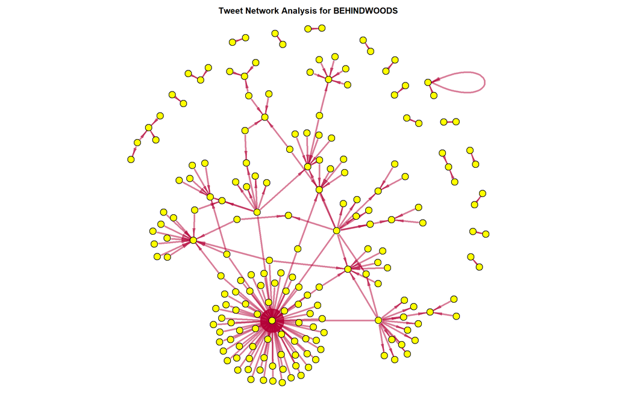

```r
par(bg="white", mar=c(1,1,1,1))
plot(tweet_graph, layout=layout.fruchterman.reingold(tweet_graph),
     vertex.color="yellow",
     vertex.size=4,
     vertex.shape="circle",
     vertex.label.color="black",
     vertex.label=NA,
     vertex.label.cex=0.85,
     vertex.label.dist=8,
     edge.arrow.size=0.8,
     edge.arrow.width=0.5,
     edge.width=3,
     edge.color=hsv(h=.95, s=1, v=.7, alpha=0.5))
title("\nTweet Network Analysis for BEHINDWOODS",cex.main=1, col.main="black")
```

### Properties of the base Network

```r
# 1. Degree Distribution
# Determining the degree of the model in a sorted format

tweet_graph.degree <-degree(tweet_graph)
head(sort(tweet_graph.degree, decreasing=TRUE),10)
```

```
##     behindwoods    ChittiRicker    PoppyCute123 VijayFansTrends
##              79              15              13              13
##  LMKMovieManiac  SureshvjSuresh      jananioffl   GuRuThalaivaa
##               9               9               8               7
##    TheHunteR_VJ     GSPrakash06
##               6               6
```

```r
# Calculating the degree distribution and plotting it against the index

tweet_graph.degree_distrib<-degree_distribution(tweet_graph, cumulative = FALSE)
sprintf("Degree Distribution of base graph")
```

```
## [1] "Degree Distribution of base graph"
```

```r
tweet_graph.degree_distrib
```

```
##  [1] 0.000000000 0.782383420 0.119170984 0.041450777 0.005181347
##  [6] 0.000000000 0.010362694 0.005181347 0.005181347 0.010362694
## [11] 0.000000000 0.000000000 0.000000000 0.010362694 0.000000000
## [16] 0.005181347 0.000000000 0.000000000 0.000000000 0.000000000
## [21] 0.000000000 0.000000000 0.000000000 0.000000000 0.000000000
## [26] 0.000000000 0.000000000 0.000000000 0.000000000 0.000000000
## [31] 0.000000000 0.000000000 0.000000000 0.000000000 0.000000000
## [36] 0.000000000 0.000000000 0.000000000 0.000000000 0.000000000
## [41] 0.000000000 0.000000000 0.000000000 0.000000000 0.000000000
## [46] 0.000000000 0.000000000 0.000000000 0.000000000 0.000000000
## [51] 0.000000000 0.000000000 0.000000000 0.000000000 0.000000000
## [56] 0.000000000 0.000000000 0.000000000 0.000000000 0.000000000
## [61] 0.000000000 0.000000000 0.000000000 0.000000000 0.000000000
## [66] 0.000000000 0.000000000 0.000000000 0.000000000 0.000000000
## [71] 0.000000000 0.000000000 0.000000000 0.000000000 0.000000000
## [76] 0.000000000 0.000000000 0.000000000 0.000000000 0.005181347
```

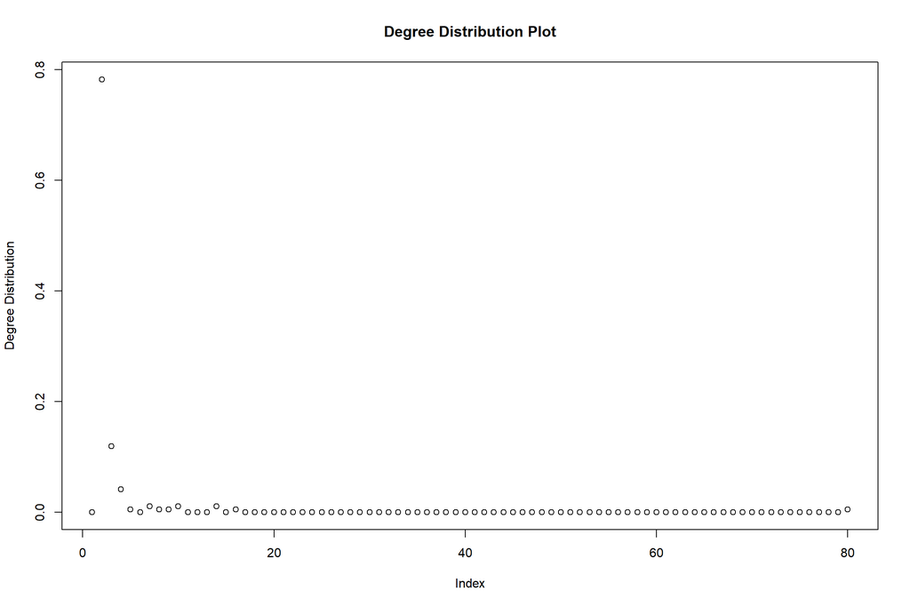

```r
plot(tweet_graph.degree_distrib, main = "Degree Distribution Plot", xlab = "Index", ylab = "Degree Distribution")
```

```r
# 2. Average Path Length of the graph

tweet_graph.apl <- average.path.length(tweet_graph,directed = FALSE, unconnected = TRUE)
sprintf("The Average Path Length of base graph is %s", tweet_graph.apl)
```

```
## [1] "The Average Path Length of base graph is 3.62983659300652"
```

```r
# 3. Clustering Coefficient

tweet_graph.clus <- transitivity(tweet_graph)
sprintf("clustering coefficient of base graph is %s", tweet_graph.clus)
```

```
## [1] "clustering coefficient of base graph is 0"
```

### Inference from the Base Network Graph

This is the base graph generated using 220 tweets from which the corresponding user information are retrieved and are denoted as nodes of the graph. It is a directed graph with more strongly connected components which is evident from the visualization of the graph.

Based on this graph, the three major properties are calculated and below is the observation on each property.

### Calculating the parameters for the below generated benchmark models for the twitter dataset

The necessary parameters for obtaining each model are calculated below.

The total number of nodes and edges are the basic measurements from a graph which are used to calculate the probability and other measures.

The probability **p** for the **random model** is the probability of drawing an edge between two arbitary vertices in a graph. This is calculated by the formula  
**p = k/(n-1)**  
where k is the average degree of the network  
n is the total number of nodes in the network

Similarly, another important parameter is the **beta** value for the **Small World Model**. This value is varied to interpolate between **a regular lattice - beta = 0** and **a random graph - beta = 1**. For the purpose of this assignment I have generated both regular lattice and a random graph with both the beta values respectively.

```r
k <- mean(degree(tweet_graph)) # Average Degree of the original network
n <- gorder(tweet_graph) # Total number of Nodes
e <- ecount(tweet_graph) # Total number of edges
p <- round(k/(n-1),5) # Probability p for the random GNP model
```

### Random (G(N,p)) model and its Properties

The random graph has been generated using Erdos-Rényi model where the nodes are connected randomly with the necessary parameters calculated above. Each edge is included in the graph with probability p independent from every other edge.

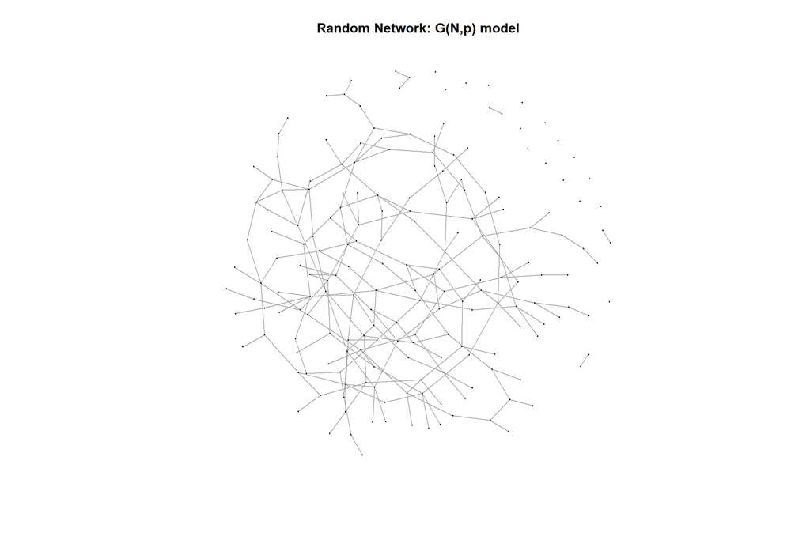

```r
gnp <- erdos.renyi.game(n, p, type = "gnp")
plot(gnp, vertex.label= NA, edge.arrow.size=0.02,vertex.size = 0.5, main = "Random Network: G(N,p) model")
```

```r
# 1. Degree Distribution
# Determining the degree of the model in a sorted format

gnp.degree <-degree(gnp)
head(sort(gnp.degree, decreasing=TRUE),10)
```

```
##  [1] 7 5 5 5 5 5 5 5 5 5
```

```r
# Calculating the degree distribution and plotting it against the index

gnp.degree_distrib<-degree_distribution(gnp, cumulative = FALSE)
sprintf("Degree Distribution of Random (G(N,p)) model")
```

```
## [1] "Degree Distribution of Random (G(N,p)) model"
```

```r
gnp.degree_distrib
```

```
## [1] 0.082901554 0.305699482 0.207253886 0.212435233 0.129533679 0.056994819
## [7] 0.000000000 0.005181347
```

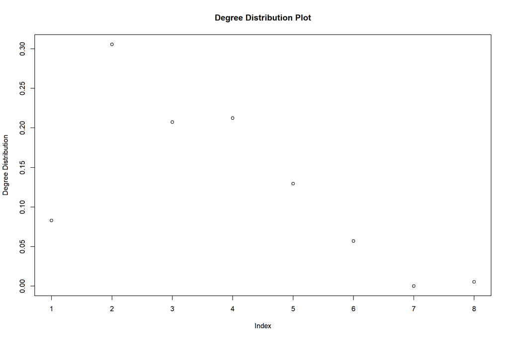

```r
plot(gnp.degree_distrib, main = "Degree Distribution Plot", xlab = "Index", ylab = "Degree Distribution")
```

```r
# 2.  Average Path Length

gnp.apl <- average.path.length(gnp,directed = FALSE, unconnected = TRUE)
sprintf("The Average path Length of Random (G(N,p)) model is %s", gnp.apl)
```

```
## [1] "The Average path Length of Random (G(N,p)) model is 6.28523585577882"
```

```r
# 3. Clustering Coefficient

gnp.global.cc <- transitivity(gnp)
sprintf("clustering coefficient of Random (G(N,p)) model with p = %s is %s", p, gnp.global.cc)
```

```
## [1] "clustering coefficient of Random (G(N,p)) model with p = 0.01052 is 0"
```

### Small World Model and its Properties

**Watts-Strogatz model** is a random graph generation model which produces small world properties and so does the name **Small World Model**. This model generates graph with **short average path length and high clustering coefficient values**. This model is also called as the *beta* model as it uses the beta value for formalution.

### Small World Model - Regular Lattice with beta = 0

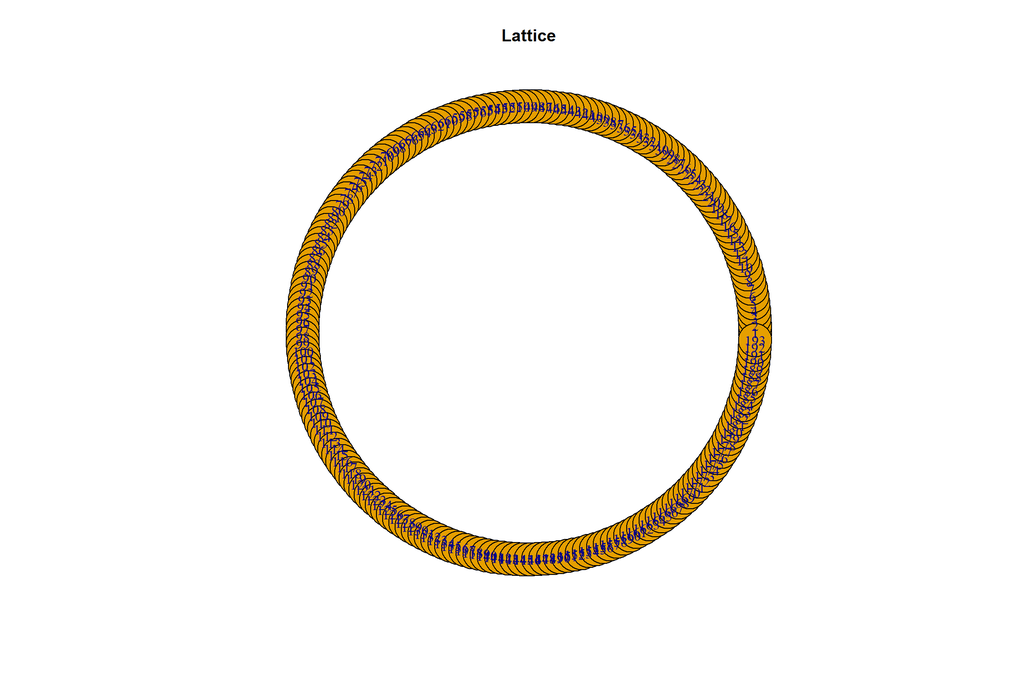

```r
# Creating a lattice with beta = 0 and getting its properties

beta=0
smw <- graph.lattice( length=n, dim=1, nei=4 )
plot(smw, layout=layout.circle(smw), main="Lattice")
```

```r
# 1. Degree Distribution
# Determining the degree of the model in a sorted format

smw.degree <-degree(smw)
head(sort(smw.degree, decreasing=TRUE),10)
```

```
##  [1] 8 8 8 8 8 8 8 8 8 8
```

```r
# Calculating the degree distribution and plotting it against the index

smw.degree_distrib = degree_distribution(smw, cumulative = FALSE)
sprintf("Degree Distribution of Small World model")
```

```
## [1] "Degree Distribution of Small World model"
```

```r
smw.degree_distrib
```

```
## [1] 0.00000000 0.00000000 0.00000000 0.00000000 0.01036269 0.01036269
## [7] 0.01036269 0.01036269 0.95854922
```

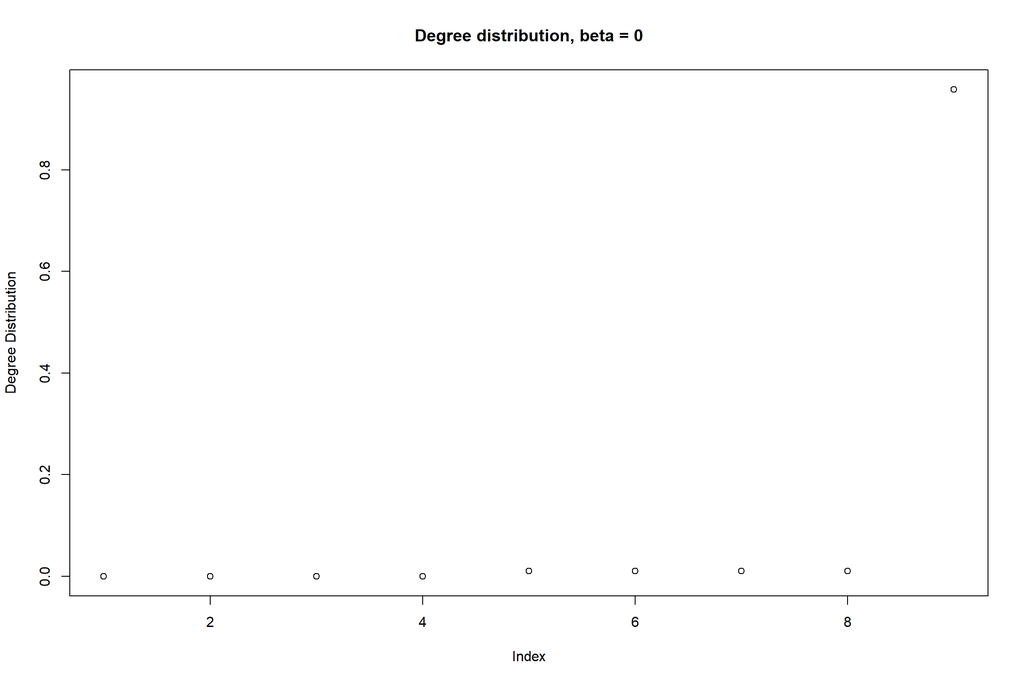

```r
plot(smw.degree_distrib, main=paste("Degree distribution, beta =", beta),
     xlab = "Index", ylab = "Degree Distribution")
```

```r
# 2. Average Path Length

smw.apl <- average.path.length(smw,directed = FALSE, unconnected = TRUE)
sprintf("The Average path Length of Small World model is %s", smw.apl)
```

```
## [1] "The Average path Length of Small World model is 16.5449050086356"
```

```r
# 3. Clustering Coefficient

smw.global.cc <- transitivity(smw)
sprintf("clustering coefficient of Small World Model with beta = %s is %s", beta, smw.global.cc)
```

```
## [1] "clustering coefficient of Small World Model with beta = 0 is 0.646101438304315"
```

### Small World Model - Random graph model with beta = 1

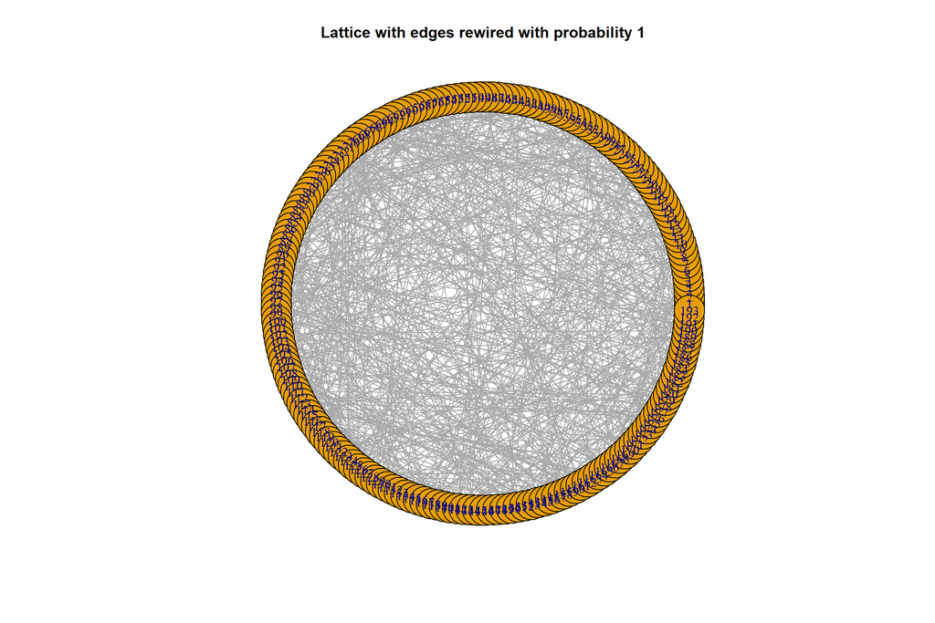

```r
# Randomly rewire edges with probability beta = 1 for the Small World Model

beta = 1
smw_rewire <- graph.lattice( length=n, dim=1, nei=4 )
smw_rewire <- rewire(smw_rewire, each_edge(p = beta, loops = FALSE))
plot(smw_rewire, layout=layout.circle(smw_rewire), main=paste("Lattice with edges rewired with probability", beta ))
```

```r
# 1. Degree Distribution
# Determining the degree of the model in a sorted format

smw_rewire.degree <-degree(smw_rewire)
head(sort(smw_rewire.degree, decreasing=TRUE),10)
```

```
##  [1] 15 14 14 14 14 14 14 13 13 13
```

```r
# Calculating the degree distribution and plotting it against the index

smw_rewire.degree_distrib = degree_distribution(smw_rewire, cumulative = FALSE)
sprintf("Degree Distribution of Small World model")
```

```
## [1] "Degree Distribution of Small World model"
```

```r
smw_rewire.degree_distrib
```

```
##  [1] 0.000000000 0.000000000 0.020725389 0.036269430 0.051813472
##  [6] 0.093264249 0.113989637 0.134715026 0.160621762 0.103626943
## [11] 0.113989637 0.067357513 0.041450777 0.025906736 0.031088083
## [16] 0.005181347
```

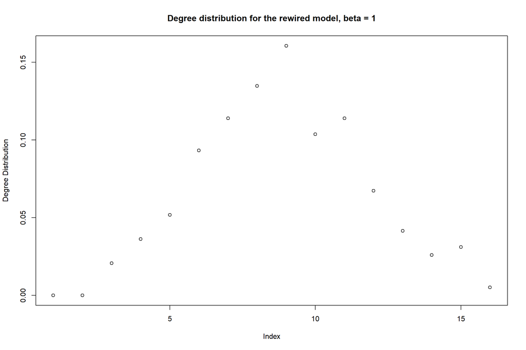

```r
plot(smw_rewire.degree_distrib, main=paste("Degree distribution for the rewired model, beta =", beta),
     xlab = "Index", ylab = "Degree Distribution")
```

```r
# 2. Average Path Length

smw_rewire.apl <- average.path.length(smw_rewire,directed = FALSE, unconnected = TRUE)
sprintf("The Average path Length of the rewired model is %s", smw_rewire.apl)
```

```
## [1] "The Average path Length of the rewired model is 2.77585276338515"
```

```r
# 3. Clustering Coefficient

smw_rewire.global.cc <- transitivity(smw_rewire)
sprintf("clustering coefficient of rewired model with beta = %s is %s", beta, smw_rewire.global.cc)
```

```
## [1] "clustering coefficient of rewired model with beta = 1 is 0.0434782608695652"
```

### Preferential Attachment Model and its Properties

In some networks, a few “hubs” have lots of connections, while every others have only has a few. This model generates these networks by a process of **preferential attachment**, in which new network members prefer to make a connection with the most popular existing members. The networks generated from this model are usually scale-free networks.

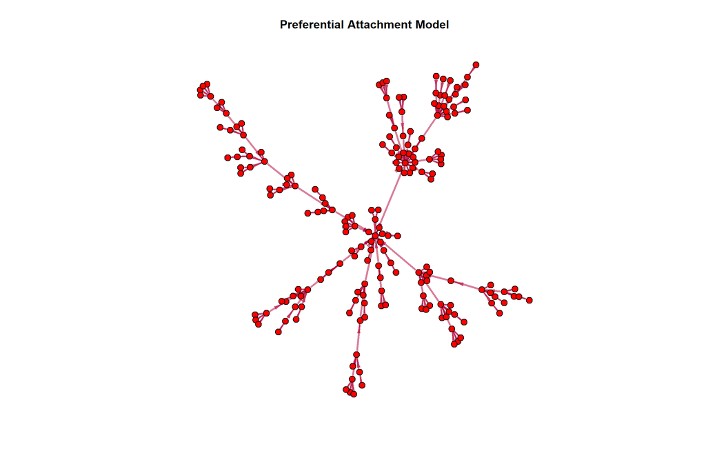

```r
pam <- sample_pa(n, power = 1, m = 1, out.dist = NULL, out.seq = NULL,
          out.pref = FALSE, zero.appeal = 1, directed = TRUE,
          algorithm = c("psumtree", "psumtree-multiple", "bag"), start.graph = NULL)
plot(pam, main = "Preferential Attachment Model",
     layout=layout.fruchterman.reingold(pam),
     vertex.color="red",
     vertex.size=4,
     vertex.shape="circle",
     vertex.label.color="black",
     vertex.label=NA,
     vertex.label.cex=0.85,
     vertex.label.dist=8,
     edge.arrow.size=0.8,
     edge.arrow.width=0.5,
     edge.width=3,
     edge.color=hsv(h=.95, s=1, v=.7, alpha=0.5))
```

```r
# 1. Degree Distribution
# Determining the degree of the model in a sorted format

pam.degree <-degree(pam)
head(sort(pam.degree, decreasing=TRUE),10)
```

```
##  [1] 20 17 13  9  7  7  6  6  6  6
```

```r
# Calculating the degree distribution and plotting it against the index

pam.degree_distribution = degree_distribution(pam, cumulative = FALSE)
sprintf("Degree Distribution of the Preferential Attachment Model")
```

```
## [1] "Degree Distribution of the Preferential Attachment Model"
```

```r
pam.degree_distribution
```

```
##  [1] 0.000000000 0.637305699 0.181347150 0.062176166 0.041450777
##  [6] 0.020725389 0.025906736 0.010362694 0.000000000 0.005181347
## [11] 0.000000000 0.000000000 0.000000000 0.005181347 0.000000000
## [16] 0.000000000 0.000000000 0.005181347 0.000000000 0.000000000
## [21] 0.005181347
```

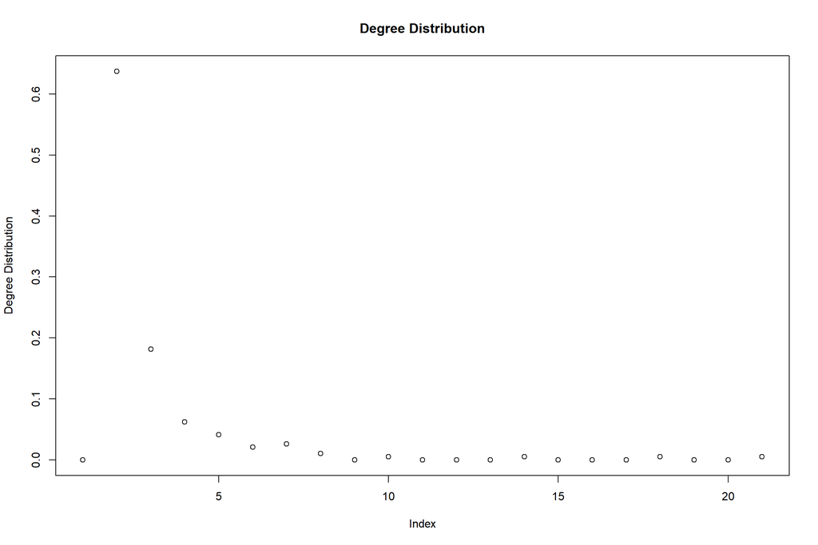

```r
plot(pam.degree_distribution, main=paste("Degree Distribution"), xlab = "Index", ylab = "Degree Distribution")
```

```r
# 2. Average Path Length

pam.apl <- average.path.length(pam,directed = FALSE, unconnected = TRUE)
sprintf("The Average path Length of the Preferential Attachment Model is %s", pam.apl)
```

```
## [1] "The Average path Length of the Preferential Attachment Model is 5.73089378238342"
```

```r
# 3. Clustering Coefficient

pam.global.cc <- transitivity(pam)
sprintf("clustering coefficient of Preferential Attachment Model is %s", pam.global.cc)
```

```
## [1] "clustering coefficient of Preferential Attachment Model is 0"
```

### Inference based on the properties

Based on this graph, the three major properties are calculated and below is the observation on each property.

1. **Degree Distribution** - From the degree distribution plot of this network, we can see that this distribution also follows power-law like the base graph. Hence, this network is also called as, scale-free network model.
2. **Average path length** - The average path length for this model is ~5 which is lesser than the Random G(N,p) model, forming a better network than Random network. However, it is less efficient network than the base network and the Small World Network model with beta = 1. Such models have their average path length increasing approximately logarithmically with the network size.
3. **Clustering Coefficient** - There is no analytical method to determine the clustering coefficient for this model and hence the result zero in our generated model. But this can be calculated empirically which is dependent on the size of the network and usually of a smaller value when compared to other models.

### Properties comparison of the generated models

[figure not shown]

```r
image1 <- "Images/Properties_Value.png"
include_graphics(image1)
```

### Comparison Table of the three important properties for the models generated

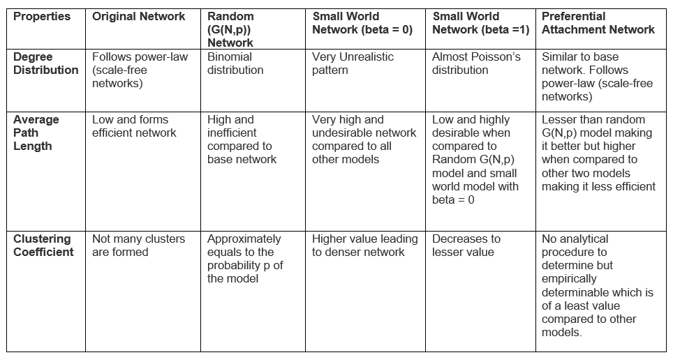

```r
image2 <- "Images/Comparison_Table.png"
include_graphics(image2)
```

### Conclusion

After carefully analyzing the Twitter network through different benchmark models, the following conclusions can be drawn:

1. From the above table information, it is evident that Preferential attachment network models exhibit similarities with the base network in terms of degree distribution and clustering coefficient. However, base network forms more efficient network than the preferential attachment network.
2. Small World network model has varying values for all the three properties based on the beta values. These networks behave like the base network in terms of average path length and clustering coefficient when beta = 1. However, the degree distribution of this model for both the cases is very unrealistic.
3. On the other hand, Random G(N,p) Network model doesn’t have any similarities with the base network. It is very clear that, base network has contrasting properties when compared to this network model.

Overall, when comparing all the network models generated in this assignment, base network model seems to be more efficient followed by Small World Network models. However, preferential attachment network model is still good in its own way when compared to random network model which under performs in terms of all the three properties.

### References

1. [Wilensky, U. (2005). NetLogo Preferential Attachment model](http://ccl.northwestern.edu/netlogo/models/PreferentialAttachment)
2. [Barabási-Albert model to understand the properties of Preferential Attachment Model](https://en.wikipedia.org/wiki/Barab%C3%A1si%E2%80%93Albert_model)
3. [Erdos-Rényi model to understand the properties Random G(N,p) Model](https://en.wikipedia.org/wiki/Erd%C5%91s%E2%80%93R%C3%A9nyi_model)
4. [Watts-Strogatz model to understrand the properties of Small World Model](https://en.wikipedia.org/wiki/Watts%E2%80%93Strogatz_model)
5. Lecture Materials from **CT5133 - Web and Network Science** module